# 08_regularization

```python
%matplotlib inline
```

## Import common Python libraries

```python
import pandas as pd
import numpy as np
import matplotlib
import matplotlib.pyplot as plt
from matplotlib.pyplot import cm
from sklearn.metrics import mean_squared_error

import warnings
warnings.filterwarnings("ignore")

from common import plot_data, plot_poly

matplotlib.rc("figure", figsize=(8, 6))

colors = cm.tab10(np.linspace(0, 1, 10))
```

## Load example data

```python
df = pd.read_csv("data/aircraft.csv", index_col=0)

train_acs = "A320,A343,A359,A388,B737,B744,B748,B752,B763,B773,B789,C550,E145,E190"
train_acs = train_acs.split(",")

df_train = df.query("index in @train_acs")
df_test = df.query("index not in @train_acs")

x = df.length.values
y = df.max_weight.values

x_train = df_train.length.values
y_train = df_train.max_weight.values

x_test = df_test.length.values
y_test = df_test.max_weight.values
```

## Write our own polynomial regression

Pay attention to the use of `scipy.linalg.inv` and `np.float128`. This is to ensure the correct inversion of the least-squares matrix.

```python
def polynomial_regression(x, y, k):
    # use scipy inv insead of np inv, slight better performace
    from scipy.linalg import inv

    X = np.vander(x, k+1, increasing=True)

    # more float precision to deal with tiny coefficients in matrix inversion
    X = X.astype(np.float128)
    Y = y.astype(np.float128)

    res = np.dot(X.T, X)
    res = np.dot(inv(res), X.T)
    res = np.dot(res, Y)

    coef = res.squeeze()

    return coef
```

### An example high-order polynomial model

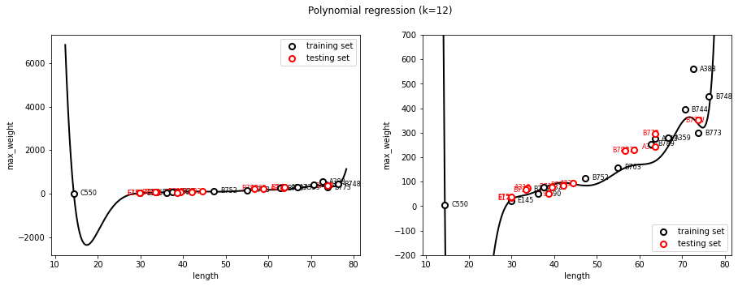

```python
k = 12
coef = polynomial_regression(x_train, y_train, k)

fig, ax = plt.subplots(1, 2, figsize=(15, 5))
plot_data(ax[0], df_train, df_test, xcol="length", ycol="max_weight", show_test=True, show_type=True)
plot_poly(ax[0], x_train, coef, color='k')
plot_data(ax[1], df_train, df_test, xcol="length", ycol="max_weight", show_test=True, show_type=True)
plot_poly(ax[1], x_train, coef, color='k')
ax[1].set_ylim([-200, 700])
plt.suptitle("Polynomial regression (k={})".format(k))
plt.show()
```

On the right is a zoomed plot from the left. We can observe that the polynomial model with k=12 apparently over fits the data.

# Our challenge:

## 💪💪 keep the same polynomial order, and ensure a Goldilocks model

# Regularization

Regularization helps us keep (regularize) the "sanity" of the model by penalize the large coefficients.

There are two common types of regularization used in machine learning: **L2** and **L1**. They are call **Ridge regression** and **Lasso regression**, respectively.

### L1 norm: Manhattan Distance

[figure not shown]

### L2 norm: Euclidean Distance

[figure not shown]

## Before L2 and L1 regularization

Recall the least-sqaures minimization problem:

$$ \mathbf{X} \mathbf{\beta} = \mathbf{y} $$

The least square method will minimize the residual sum of squares (RSS) in matrix format as:

$$ RSS(\beta) = (\mathbf{y} - \mathbf{X} \beta)^T (\mathbf{y} - \mathbf{X} \beta) $$

In regularization, instead of minimize the RSS directly, we minimize the **(RSS + Penalty Term)**.

The cost function becomes:

$$ Q(\beta) = RSS(\beta) + \text{penalty} $$

## L2 regularization - Ridge regression

In Ridge regression, the penalty term is defined as:

$$ \alpha ||\beta||_2^2 $$

which is the square of L2 norm of all the coefficient. Here $\alpha$ is a scalar value and $\beta$ is a vector.

Then, we are going to minimize the new cost function, denoted as $Q(\beta)$:

$$ Q(\beta) = RSS(\beta) + \alpha ||\beta||_2^2 $$

This equals to:

$$ Q(\beta) = (\mathbf{y} - \mathbf{X} \beta)^T (\mathbf{y} - \mathbf{X} \beta) + \alpha \beta^T \beta $$

In order to obtain $\beta$, we need to set the gradient of $Q(\beta)$ to zero. The gradient of $Q$ can be calculated as:

$$ \nabla Q(\beta) = \nabla (\mathbf{y} - \mathbf{X} \beta)^T (\mathbf{y} - \mathbf{X} \beta) + \nabla \alpha \beta^T \beta $$

In earlier section, we already know the gradient of the first terms, and the gradient of the second term is simply $2 \alpha \beta$, we have:

$$ \nabla Q(\beta) = -2 \mathbf{X}^T(\mathbf{y} - \mathbf{X} \beta) + 2 \alpha \beta $$

Set it to zero, we can calculate the **regularized coefficients** as:

$$ -2 \mathbf{X}^T(\mathbf{y} - \mathbf{X} \beta) + 2 \alpha \beta = 0 \\ \beta = (\mathbf{X}^T \mathbf{X} + \alpha I)^{-1} \mathbf{X}^T \mathbf{y} $$

where $I$ is the identity matrix.

## Python implementation

Now we can construct our own Ridge regression function:

```python
def polynomial_regression_l2(x, y, k, alpha):
    from scipy.linalg import inv

    X = np.vander(x, k+1, increasing=True)

    X = X.astype(np.float128)
    Y = y.astype(np.float128)

    res = np.dot(X.T, X)
    res = res + alpha * np.identity(k+1)
    res = np.dot(inv(res), X.T)
    res = np.dot(res, y)

    coef = res.squeeze()

    return coef
```

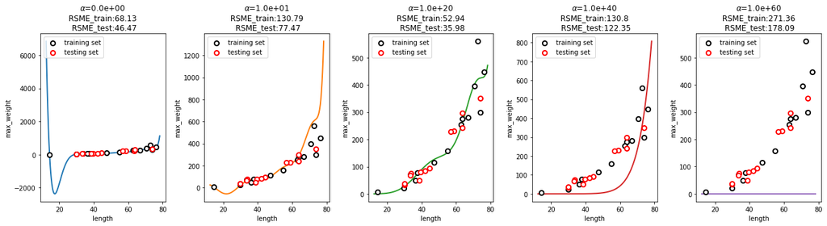

```python
k = 12
alphas = [0, 1e1, 1e20, 1e40, 1e60]

fig, axes = plt.subplots(1, 5, figsize=(18, 5))

for i, alpha in enumerate(alphas):
    ax = axes.flatten()[i]

    coef = polynomial_regression_l2(x_train, y_train, k, alpha)
    model = np.poly1d(coef[::-1]) # numpy coefficient is reversed

    RSME_train = np.sqrt(mean_squared_error(y_train, model(x_train))).round(2)
    RSME_test = np.sqrt(mean_squared_error(y_test, model(x_test))).round(2)

    plot_data(ax, df_train, df_test, xcol="length", ycol="max_weight", show_test=True)
    plot_poly(ax, x_train, coef, color=colors[i])

    ax.set_title('$\\alpha$={:.1e} \n RSME_train:{} \n RSME_test:{}'.format(alpha, RSME_train, RSME_test))
    ax.legend(loc="upper left")
plt.tight_layout()
plt.show()
```

### 🤔🤔 Take a look at the first and last plot, and think "why"

Recall the gradient of the cost function:

$$ \nabla Q(\beta) = -2 \mathbf{X}^T(\mathbf{y} - \mathbf{X} \beta) + 2 \alpha \beta = 0 $$

## Take a look at the maximum coefficients (L2)

```python
for i, alpha in enumerate(alphas):
    coef = polynomial_regression_l2(x_train, y_train, k, alpha)
    model = np.poly1d(coef[::-1]) # numpy coefficient is reversed
    print("Alpha: {:.1e} \t Maximum coefficient: {:.2e}".format(alpha, max(abs(coef))))
```

```
Alpha: 0.0e+00 	 Maximum coefficient: 6.96e+05
Alpha: 1.0e+01 	 Maximum coefficient: 1.51e+00
Alpha: 1.0e+20 	 Maximum coefficient: 4.09e-10
Alpha: 1.0e+40 	 Maximum coefficient: 1.07e-18
Alpha: 1.0e+60 	 Maximum coefficient: 4.82e-35
```

## L2 regularization using Scikit-Learn

Next we will implement the Ridge regression using Scikit-Learn

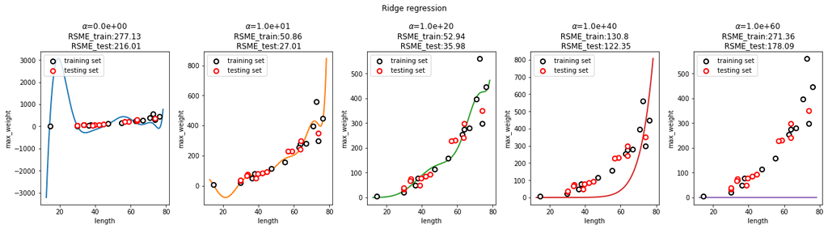

```python
from sklearn.pipeline import make_pipeline
from sklearn.preprocessing import PolynomialFeatures
from sklearn.linear_model import Ridge

k = 12
alphas = [0, 1e1, 1e20, 1e40, 1e60]

X_train = x_train.reshape(-1, 1)
X_test = x_test.reshape(-1, 1)

fig, axes = plt.subplots(1, len(alphas), figsize=(18, 5))
for i, alpha in enumerate(alphas):
    ax = axes.flatten()[i]

    model = make_pipeline(PolynomialFeatures(k), Ridge(alpha=alpha, fit_intercept=False))
    model.fit(X_train, y_train)

    coef = model['ridge'].coef_

    RSME_train = np.sqrt(mean_squared_error(y_train, model.predict(X_train))).round(2)
    RSME_test = np.sqrt(mean_squared_error(y_test, model.predict(X_test))).round(2)

    plot_data(ax, df_train, df_test, xcol="length", ycol="max_weight", show_test=True)
    plot_poly(ax, x_train, coef, color=colors[i])
    ax.set_title('$\\alpha$={:.1e} \n RSME_train:{} \n RSME_test:{}'.format(alpha, RSME_train, RSME_test))
    ax.legend(loc="upper left")
plt.suptitle('Ridge regression')
plt.tight_layout()
plt.show()
```

Notice the difference with our earlier results when $\alpha = 0$?

🤔 Guess what is the reason?

## L1 regularization - Lasso regression

In Lasso regression, instead of L2 norm penalty, we use the L1 norm penalty

$$ \alpha ||\beta|| $$

Then, we are minimizing the new cost function $Q(\beta)$:

$$ Q(\beta) = RSS(\beta) + \alpha ||\beta|| $$

Which becomes:

$$ Q(\beta) = (\mathbf{y} - \mathbf{X} \beta)^T (\mathbf{y} - \mathbf{X} \beta) + \alpha ||\beta|| $$

In order to obtain $\beta$, we need to set the gradient of $Q(\beta)$ to zero. The gradient can be calculated as:

$$ \nabla Q(\beta) = \nabla (\mathbf{y} - \mathbf{X} \beta)^T (\mathbf{y} - \mathbf{X} \beta) + \alpha ~ sign(\beta) = 0 $$

Where $sign(\beta)$ is the element-wise sign of $\beta$.

Because of this, there is no "clean" closed form algebraic solutions, as compared to L2 regularization.

Commonly, we can use the gradient descent (coordinate descent) to obtain the solution.

We are going to leverage the Scikit-Learn package to perform L1 regression.

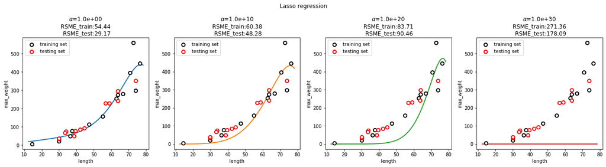

```python
from sklearn.pipeline import make_pipeline
from sklearn.preprocessing import PolynomialFeatures
from sklearn.linear_model import LinearRegression, Lasso

k = 12
alphas = [1, 1e10, 1e20, 1e30]

X_train = x_train.reshape(-1, 1)
X_test = x_test.reshape(-1, 1)

fig, axes = plt.subplots(1, len(alphas), figsize=(18, 5))
for i, alpha in enumerate(alphas):
    ax = axes.flatten()[i]

    model = make_pipeline(PolynomialFeatures(k), Lasso(alpha=alpha, fit_intercept=False))
    model.fit(X_train, y_train)

    coef = model['lasso'].coef_
    RSME_train = np.sqrt(mean_squared_error(y_train, model.predict(X_train))).round(2)
    RSME_test = np.sqrt(mean_squared_error(y_test, model.predict(X_test))).round(2)

    plot_data(ax, df_train, df_test, xcol="length", ycol="max_weight", show_test=True)
    plot_poly(ax, x_train, coef, color=colors[i])
    ax.set_title('$\\alpha$={:.1e} \n RSME_train:{} \n RSME_test:{}'.format(alpha, RSME_train, RSME_test))
    ax.legend(loc="upper left")
plt.suptitle('Lasso regression')
plt.tight_layout()
plt.show()
```

### Take a look at the last plot, and think "why?"

Recall the gradient of the cost function:

$$ \nabla Q(\beta) = \nabla (\mathbf{y} - \mathbf{X} \beta)^T (\mathbf{y} - \mathbf{X} \beta) + \alpha ~ sign(\beta) = 0 $$

## Take a look at the maximum coefficients (L1)

```python
for i, alpha in enumerate(alphas):
    model = make_pipeline(PolynomialFeatures(k), Lasso(alpha=alpha, fit_intercept=False))
    model.fit(X_train, y_train)
    coef = model['lasso'].coef_
    model = np.poly1d(coef[::-1]) # numpy coefficient is reversed
    print("Alpha: {:.1e} \t Maximum coefficient: {:.2e}".format(alpha, max(abs(coef))))
```

```
Alpha: 1.0e+00 	 Maximum coefficient: 1.67e+00
Alpha: 1.0e+10 	 Maximum coefficient: 8.12e-09
Alpha: 1.0e+20 	 Maximum coefficient: 1.07e-17
Alpha: 1.0e+30 	 Maximum coefficient: 0.00e+00
```

# Comparing L1 and L2 regularization results

## Coefficients with L1 regularization

Using the "best" $\alpha = 10^{10}$

```python
model = make_pipeline(PolynomialFeatures(k), Lasso(alpha=1e10, fit_intercept=False))
model.fit(X_train, y_train)
coef = model['lasso'].coef_
print(coef)
```

```
[ 0.00000000e+00  0.00000000e+00  0.00000000e+00  0.00000000e+00
  0.00000000e+00  0.00000000e+00  8.11828971e-09 -2.54500233e-11
 -3.13339217e-13 -2.28072316e-15 -1.68496935e-17 -1.31732356e-19
 -1.19565204e-21]
```

## Coefficients with L2 regularization

Using the "best" $\alpha = 10^{20}$

```python
model = make_pipeline(PolynomialFeatures(k), Ridge(alpha=1e20, fit_intercept=False))
model.fit(X_train, y_train)
coef = model['ridge'].coef_
print(coef)
```

```
[ 1.00778724e-19  2.01151826e-18  4.16741449e-17  8.41493304e-16
  1.54367688e-14  2.38281921e-13  2.88957221e-12  3.05363490e-11
  4.08594553e-10 -2.38598796e-11  5.23319667e-13 -5.09692728e-15
  1.85681343e-17]
```

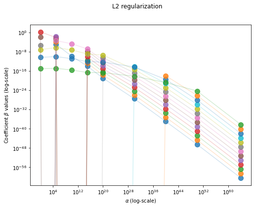

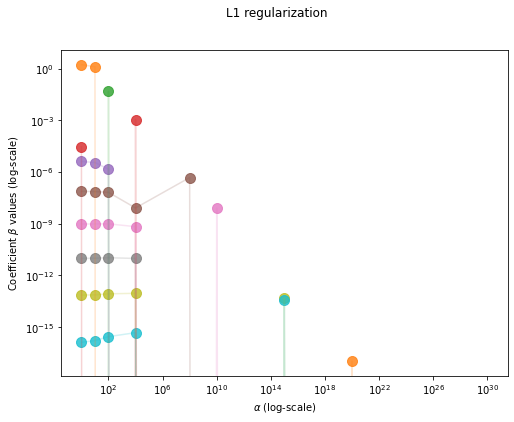

```python
l2_alphas = [1, 1e5, 1e10, 1e15, 1e20, 1e30, 1e40, 1e50, 1e64]
res = []
for i, alpha in enumerate(l2_alphas):
    model = make_pipeline(PolynomialFeatures(k), Ridge(alpha=alpha, fit_intercept=False))
    model.fit(X_train, y_train)
    res.append(model['ridge'].coef_)

res = np.array(res)
for i in range(res.shape[1]):
    plt.plot(l2_alphas, res[:, i], alpha=0.2)
    plt.scatter(l2_alphas, res[:, i], alpha=0.8, s=100)
plt.xscale('log')
plt.yscale('log')
plt.xlabel('$\\alpha$ (log-scale)')
plt.ylabel('Coefficient $\\beta$ values (log-scale)')
plt.suptitle('L2 regularization')
plt.show()

l1_alphas = [1, 1e1, 1e2, 1e4, 1e8, 1e10, 1e15, 1e20, 1e30]
res = []
for i, alpha in enumerate(l1_alphas):
    model = make_pipeline(PolynomialFeatures(k), Lasso(alpha=alpha, fit_intercept=False))
    model.fit(X_train, y_train)
    coef = model['lasso'].coef_
    res.append(coef)

res = np.array(res)
for i in range(res.shape[1]):
    plt.plot(l1_alphas, res[:, i], alpha=0.2)
    plt.scatter(l1_alphas, res[:, i], alpha=0.8, s=100)
plt.xscale('log')
plt.yscale('log')
plt.xlabel('$\\alpha$ (log-scale)')
plt.ylabel('Coefficient $\\beta$ values (log-scale)')
plt.suptitle('L1 regularization')
plt.show()
```

# Final question 🤔🤔🤔

### How would you chose the best $\alpha$ for these regularized regression models?